# 공간정보분석

[ASS-06] Zulu ‘Attack Launched!’ by: 박경준, 김예진, 김예원, 서용훈

# 1. Abstract

# 2. Introduction

도시지리학에서 해당 지역의 치안과 범죄 발생 건수와 범죄율은 지역에 대한 사람들의 선호를 결정하는데 결정적인 요소로서 연구대상으로 많이 사용되고 있습니다. 도시의 특성과 성격을 분석하는데 유의미한 지표라고 할 수 있는 범죄율은, 여러 요인의 영향을 받습니다. 범죄에 영향을 주는 대표적인 요소로는 공공재로서 치안의 공급도를 한 눈에 볼 수 있는 1인당 CCTV나 경찰력, 그리고 소득 등이 있다고 볼 수 있습니다. 이에 저희 Zulu 조는 지역의 치안력, 순이동, GRDP, 기초수급자 비율을 활용해 범죄율에 대한 여러 분석을 진행해보기로 했습니다.

# 3. Methods

## 3.1. 라이브러러리 설치

```r
library(car)
library(DescTools)
library(GGally)
library(gridExtra)
library(ggplot2)
library(ggformula)
library(tidyverse)
library(readxl)
library(knitr)
library(rmdformats)
library(broom)
```

## 3.2. 자료 구득

범죄율과 1만명당 CCTV, 1만명당 경찰수는 2016년 SBS데이터저널리즘 마부작침 팀에서 발표한 ’범죄여지도’자료를 활용했고, GRDP와 순이동, 주민등록인구대비 기초 수급자 비율은 통계청 국가통계포털에서 발표한 2016년 기준 자료를 활용했습니다.

```r
grdp <- read.csv(file = "grdp2016.csv")
movement <- read.csv(file = "emigration2016.csv")
crimedata <- read.csv(file = "crime2016.csv")
tbl <- read.csv("기초생활수급자.csv")
population <- read.csv("인구.csv")
```

## 3.3. 자료 정제하기

### 3.3.1. 기초수급자 자료 정제

```r
tbl <- mutate(tbl, name = paste(tbl$통계시도명, tbl$통계시군구명))
tbl <- aggregate(수급자수 ~ name, tbl, sum)
tbl <- rename(tbl, 지역명 = name)
```

### 3.3.2. 순이동 자료 정제

순이동 자료 행렬에서 항목 이름 변경하기

```r
movement <- rename(movement, 지역명 = 행정구역.시군구.별)
movement <- rename(movement, 유입인구 = X2016)
movement <- rename(movement, 유출인구 = X2016.1)
movement <- rename(movement, 순이동 = X2016.2)
```

순이동자료에서 합계행, 신생자치단체, 없어진 자치단체로서 유의미한 통계자료 없는 행 제거

```r
movement <- movement[-c(1, 2, 3, 29, 46, 55, 66, 72, 78, 84, 86, 115, 116, 117, 118,
    119, 121, 124, 125, 126, 127, 128, 147, 151, 160, 170, 171, 178, 179, 194, 199,
    204, 219, 243, 244, 246, 247, 249, 259, 267, 270, 271), ]
```

### 3.3.3. GRDP 자료 정제

소계 없는 행렬데이터 만들고 병합

```r
grdpdata <- subset(grdp, !행정구역소 == "소계")
grdpdata <- mutate(grdpdata, 지역명 = paste(grdpdata$행정구역대, grdpdata$행정구역소))
grdpdata <- subset(grdpdata, select = -행정구역대)
grdpdata <- subset(grdpdata, select = -행정구역소)
grdpdata <- rename(grdpdata, GRDP = X2016)
```

### 3.3.4. 범죄율 자료 정제

```r
crimedata <- mutate(crimedata, 지역명 = paste(crimedata$시도, crimedata$시군구))
crimedata <- select(crimedata, 4, 13:15)
crimedata <- rename(crimedata, 만명당CCTV = X1만명당.CCTV)
crimedata <- rename(crimedata, 경찰한명담당인구 = X1인당.담당인구)
```

### 3.3.5. 자료 통합 후 수급률 구하기

```r
finaldata <- list(tbl, grdpdata, crimedata, movement, population) %>% reduce(inner_join,
    by = "지역명")

t.rate <- finaldata$수급자수/finaldata$주민등록인구수
finaldata <- finaldata %>% mutate(t.rate)
finaldata <- finaldata %>% rename(crime = 만명당.5대범죄, cctv = 만명당CCTV, police = 경찰한명담당인구,
    migration = 순이동)
finaldata$migration <- as.numeric(finaldata$migration)
```

### 3.3.6. 데이터 분포 확인

## datatable

```r
str(finaldata)
```

```
'data.frame':   188 obs. of  11 variables:
 $ 지역명        : chr  "강원도 강릉시" "강원도 고성군" "강원도 동해시" "강원도 삼척시" ...
 $ 수급자수      : int  8722 1355 3623 3343 1178 1443 11630 1219 1423 1926 ...
 $ GRDP          : int  4854518 951171 2616335 2273273 867428 1297094 7945326 1381148 1329883 1592046 ...
 $ crime         : num  126.9 67.4 100.4 120.7 54.6 ...
 $ cctv          : num  30.9 67.1 53.6 31 77 ...
 $ police        : num  543 253 407 319 238 ...
 $ 유입인구      : Factor w/ 248 levels "0","10058","10358",..: 92 161 4 236 98 144 189 131 117 164 ...
 $ 유출인구      : Factor w/ 248 levels "0","10020","10131",..: 98 163 11 244 105 146 177 157 128 189 ...
 $ migration     : num  99 166 115 3 24 228 202 114 62 128 ...
 $ 주민등록인구수: int  213846 30114 93297 69599 24010 40073 337979 32720 38718 48013 ...
 $ t.rate        : num  0.0408 0.045 0.0388 0.048 0.0491 ...
```

```r
head(finaldata)
```

```
         지역명 수급자수    GRDP  crime  cctv police 유입인구 유출인구
1 강원도 강릉시     8722 4854518 126.91 30.91 542.76    30907    31404
2 강원도 고성군     1355  951171  67.41 67.08 253.06     5011     4816
3 강원도 동해시     3623 2616335 100.43 53.59 407.41    10520    11151
4 강원도 삼척시     3343 2273273 120.69 31.03 319.26     8483     9508
5 강원도 양구군     1178  867428  54.56 77.05 237.72     3242     3384
6 강원도 영월군     1443 1297094  60.14 75.11 288.29     4385     4316
  migration 주민등록인구수     t.rate
1        99         213846 0.04078636
2       166          30114 0.04499568
3       115          93297 0.03883297
4         3          69599 0.04803230
5        24          24010 0.04906289
6       228          40073 0.03600928
```

```r
summary(finaldata)
```

```
    지역명             수급자수          GRDP              crime
 Length:188         Min.   :  269   Min.   :  244797   Min.   : 34.91
 Class :character   1st Qu.: 2401   1st Qu.: 1368332   1st Qu.: 69.37
 Mode  :character   Median : 4868   Median : 3140862   Median : 87.47
                    Mean   : 6507   Mean   : 5653618   Mean   : 97.25
                    3rd Qu.: 8802   3rd Qu.: 6553801   3rd Qu.:112.06
                    Max.   :24889   Max.   :55136745   Max.   :409.00
      cctv            police         유입인구      유출인구     migration
 Min.   : 10.41   Min.   :125.4   10058  :  1   10131  :  1   Min.   :  2.00
 1st Qu.: 29.68   1st Qu.:323.4   10358  :  1   10181  :  1   1st Qu.: 59.75
 Median : 42.98   Median :447.5   10520  :  1   10267  :  1   Median :117.50
 Mean   : 50.78   Mean   :457.2   10559  :  1   10825  :  1   Mean   :119.73
 3rd Qu.: 64.51   3rd Qu.:581.1   105735 :  1   108949 :  1   3rd Qu.:178.25
 Max.   :206.70   Max.   :989.8   10612  :  1   10948  :  1   Max.   :242.00
 주민등록인구수        t.rate
 Min.   :  10001   Min.   :0.01085
 1st Qu.:  52135   1st Qu.:0.03029
 Median : 113943   Median :0.04060
 Mean   : 193754   Mean   :0.04061
 3rd Qu.: 311200   3rd Qu.:0.04971
 Max.   :1194041   Max.   :0.08584
 [ getOption("max.print") 에 도달했습니다 -- 1 행들을 생략합니다 ]
```

```r
DescTools::Desc(finaldata)
```

```
------------------------------------------------------------------------------
Describe finaldata (data.frame):

data frame: 188 obs. of  11 variables
        188 complete cases (100.0%)

  Nr  ColName         Class      NAs  Levels
  1   지역명          character  .
  2   수급자수        integer    .
  3   GRDP            integer    .
  4   crime           numeric    .
  5   cctv            numeric    .
  6   police          numeric    .
  7   유입인구        factor     .    (248): 1-0, 2-10058, 3-10358, 4-10520,
                                      5-10559, ...
  8   유출인구        factor     .    (248): 1-0, 2-10020, 3-10131, 4-10181,
                                      5-10267, ...
  9   migration       numeric    .
  10  주민등록인구수  integer    .
  11  t.rate          numeric    .


------------------------------------------------------------------------------
1 - 지역명 (character)

  length      n    NAs unique levels  dupes
     188    188      0    188    188      n
         100.0%   0.0%

            level  freq  perc  cumfreq  cumperc
1   강원도 강릉시     1  0.5%        1     0.5%
2   강원도 고성군     1  0.5%        2     1.1%
3   강원도 동해시     1  0.5%        3     1.6%
4   강원도 삼척시     1  0.5%        4     2.1%
5   강원도 양구군     1  0.5%        5     2.7%
6   강원도 영월군     1  0.5%        6     3.2%
7   강원도 원주시     1  0.5%        7     3.7%
8   강원도 인제군     1  0.5%        8     4.3%
9   강원도 정선군     1  0.5%        9     4.8%
10  강원도 철원군     1  0.5%       10     5.3%
11  강원도 춘천시     1  0.5%       11     5.9%
12  강원도 태백시     1  0.5%       12     6.4%
... etc.
 [list output truncated]
```

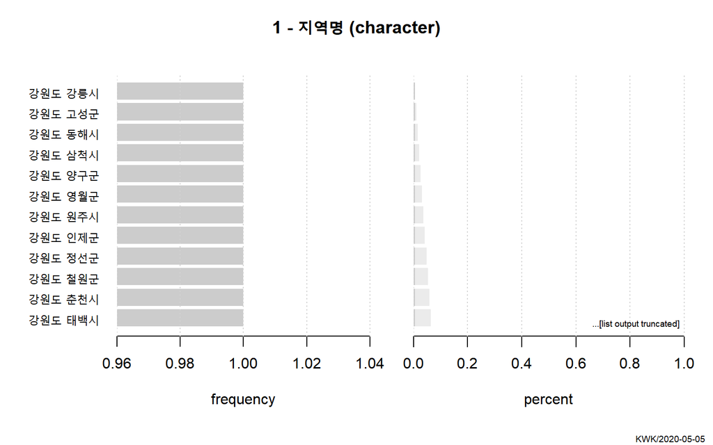

```
------------------------------------------------------------------------------
2 - 수급자수 (integer)

     length         n       NAs    unique        0s       mean     meanCI
        188       188         0       187         0   6'507.19   5'745.04
               100.0%      0.0%                0.0%              7'269.34

        .05       .10       .25    median       .75        .90        .95
   1'327.70  1'468.00  2'400.75  4'868.50  8'801.50  14'261.30  16'709.35

      range        sd     vcoef       mad       IQR       skew       kurt
  24'620.00  5'297.26      0.81  4'241.72  6'400.75       1.26       1.12

lowest : 269, 898, 1'040, 1'047, 1'071
highest: 21'071, 22'680, 23'335, 23'783, 24'889
```

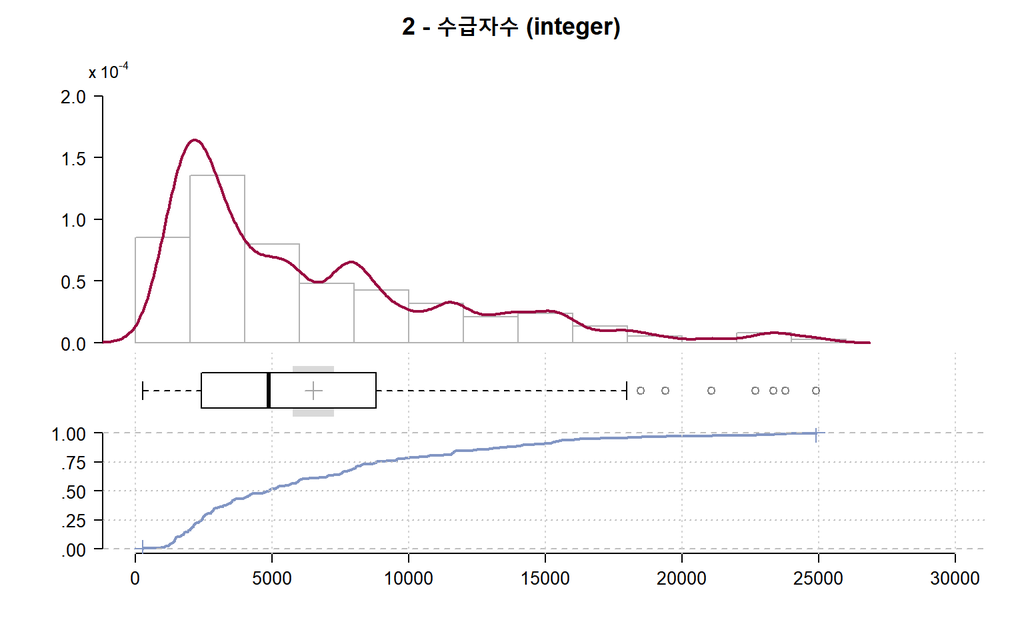

```
------------------------------------------------------------------------------
3 - GRDP (integer)

      length             n           NAs        unique            0s
         188           188             0           = n             0
                    100.0%          0.0%                        0.0%

         .05           .10           .25        median           .75
  647'101.45    794'546.30  1'368'331.75  3'140'862.00  6'553'801.00

       range            sd         vcoef           mad           IQR
    5.49e+07  7'666'003.83          1.36  3'232'469.04  5'185'469.25

          mean        meanCI
  5'653'617.78  4'550'662.29
                6'756'573.26

           .90           .95
      1.09e+07      2.22e+07

          skew          kurt
          3.46         15.28

lowest : 244'797, 385'039, 459'213, 476'103, 548'014
highest: 3e+07, 3e+07, 3e+07, 5e+07, 6e+07
```

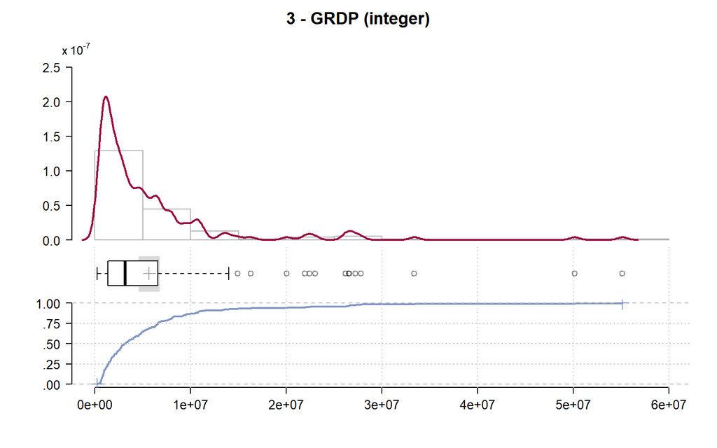

```
------------------------------------------------------------------------------
4 - crime (numeric)

    length        n      NAs   unique        0s      mean    meanCI
       188      188        0      186         0   97.2522   90.2469
             100.0%     0.0%               0.0%            104.2576

       .05      .10      .25   median       .75       .90       .95
   51.7365  54.6300  69.3675  87.4750  112.0625  132.7120  160.3975

     range       sd    vcoef      mad       IQR      skew      kurt
  374.0900  48.6902   0.5007  30.4081   42.6950    3.3009   15.7394

lowest : 34.91, 37.06, 38.76, 43.71, 44.14
highest: 217.77, 296.59, 306.73, 377.73, 409.0
```

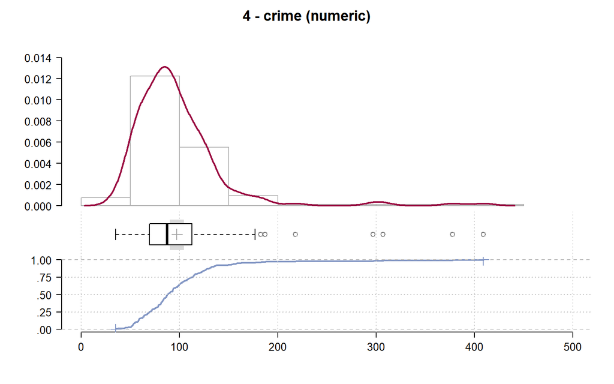

```
------------------------------------------------------------------------------
5 - cctv (numeric)

    length        n      NAs   unique       0s     mean    meanCI
       188      188        0      = n        0  50.7777   46.3944
             100.0%     0.0%              0.0%            55.1610

       .05      .10      .25   median      .75      .90       .95
   16.0365  20.1300  29.6775  42.9800  64.5125  84.7670  102.5735

     range       sd    vcoef      mad      IQR     skew      kurt
  196.2900  30.4656   0.6000  23.4547  34.8350   1.7483    4.7513

lowest : 10.41, 10.89, 11.81, 12.13, 12.37
highest: 131.67, 133.12, 155.14, 177.84, 206.7
```

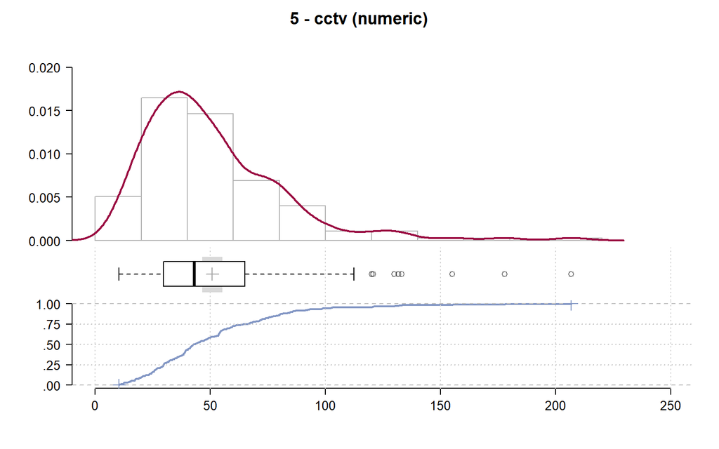

```
------------------------------------------------------------------------------
6 - police (numeric)

    length         n       NAs    unique        0s      mean    meanCI
       188       188         0       = n         0  457.2343  433.0252
              100.0%      0.0%                0.0%            481.4434

       .05       .10       .25    median       .75       .90       .95
  230.8050  253.5850  323.3550  447.5000  581.0625  672.9870  739.6410

     range        sd     vcoef       mad       IQR      skew      kurt
  864.4000  168.2636    0.3680  190.0990  257.7075    0.4412   -0.3280

lowest : 125.37, 136.37, 144.9, 172.43, 202.09
highest: 811.2, 827.04, 870.98, 883.27, 989.77
```

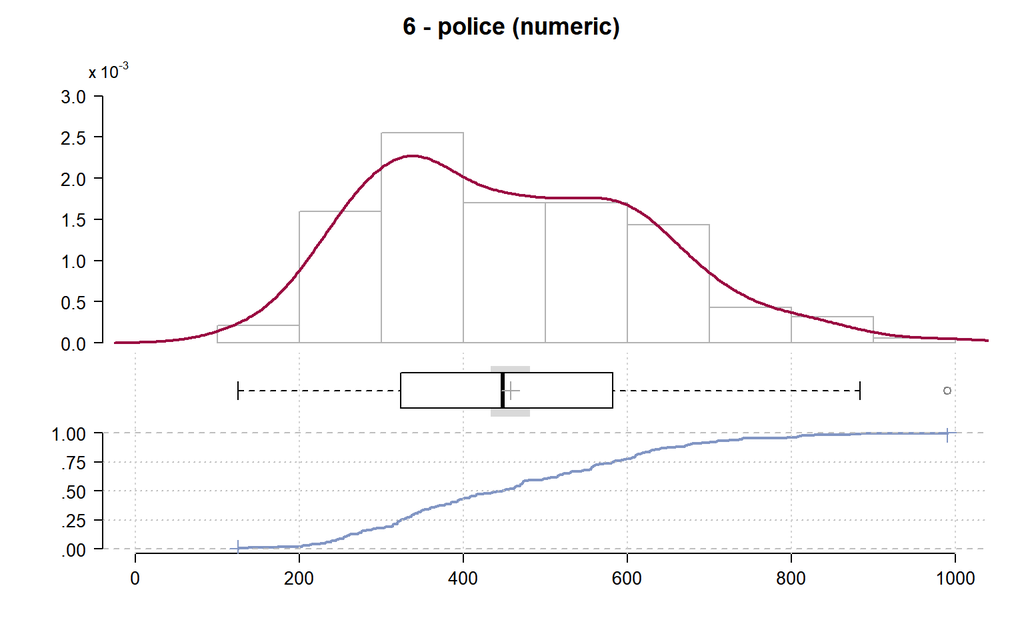

```
------------------------------------------------------------------------------
7 - 유입인구 (factor)

  length      n    NAs unique levels  dupes
     188    188      0    188    248      n
         100.0%   0.0%

     level  freq  perc  cumfreq  cumperc
1    10058     1  0.5%        1     0.5%
2    10358     1  0.5%        2     1.1%
3    10520     1  0.5%        3     1.6%
4    10559     1  0.5%        4     2.1%
5   105735     1  0.5%        5     2.7%
6    10612     1  0.5%        6     3.2%
7    10957     1  0.5%        7     3.7%
8    11446     1  0.5%        8     4.3%
9    11899     1  0.5%        9     4.8%
10   12210     1  0.5%       10     5.3%
11   12245     1  0.5%       11     5.9%
12   12402     1  0.5%       12     6.4%
... etc.
 [list output truncated]
```

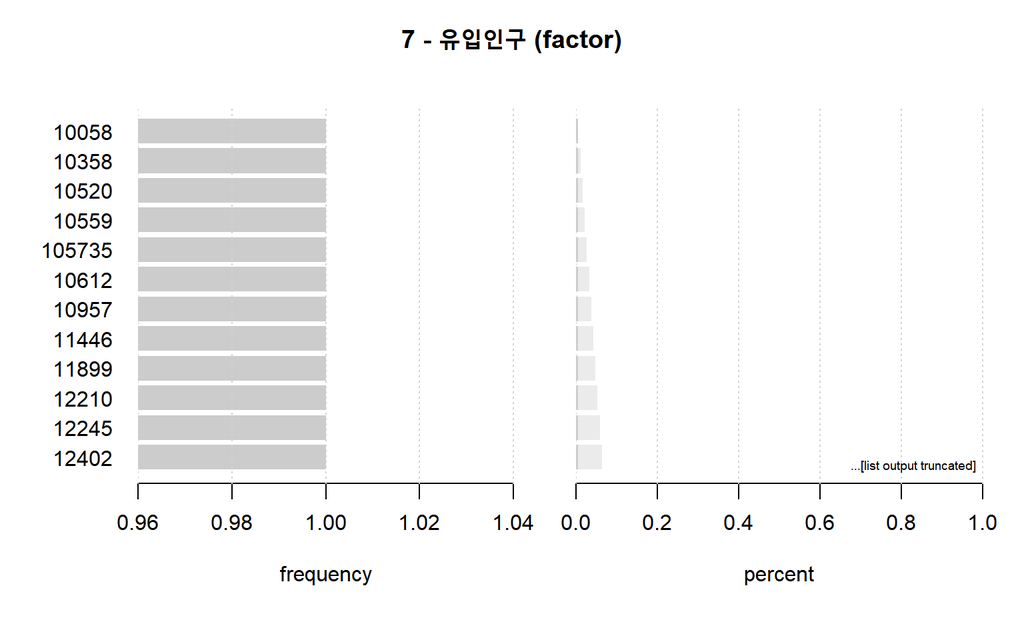

```
------------------------------------------------------------------------------
8 - 유출인구 (factor)

  length      n    NAs unique levels  dupes
     188    188      0    188    248      n
         100.0%   0.0%

     level  freq  perc  cumfreq  cumperc
1    10131     1  0.5%        1     0.5%
2    10181     1  0.5%        2     1.1%
3    10267     1  0.5%        3     1.6%
4    10825     1  0.5%        4     2.1%
5   108949     1  0.5%        5     2.7%
6    10948     1  0.5%        6     3.2%
7    11151     1  0.5%        7     3.7%
8    11154     1  0.5%        8     4.3%
9   112735     1  0.5%        9     4.8%
10   11697     1  0.5%       10     5.3%
11   11819     1  0.5%       11     5.9%
12   12112     1  0.5%       12     6.4%
... etc.
 [list output truncated]
```

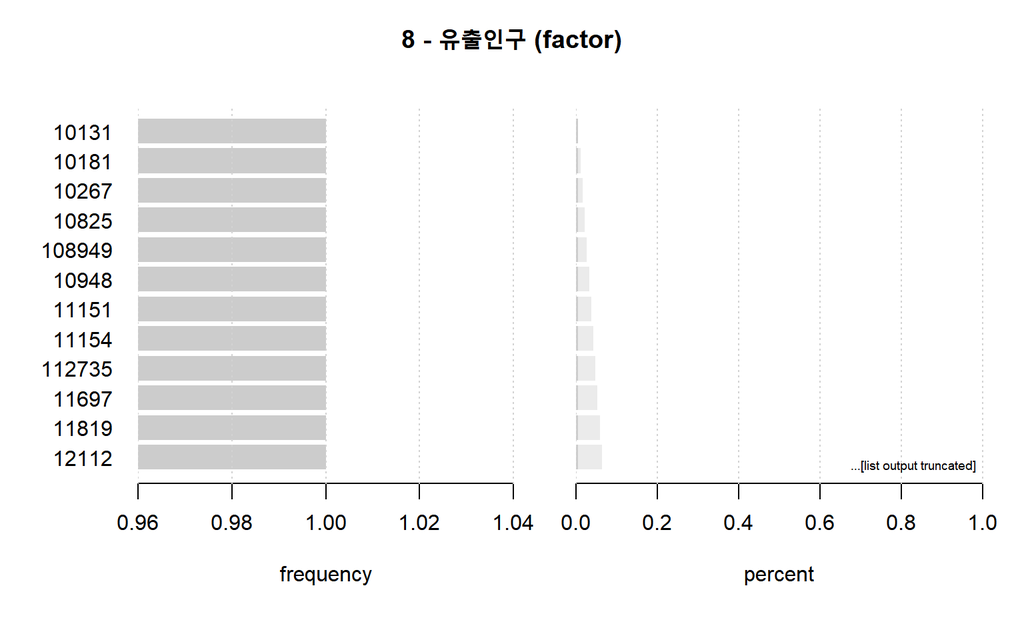

```
------------------------------------------------------------------------------
9 - migration (numeric)

  length       n    NAs  unique      0s    mean  meanCI
     188     188      0     186       0  119.73  109.81
          100.0%   0.0%            0.0%          129.66

     .05     .10    .25  median     .75     .90     .95
   15.35   25.00  59.75  117.50  178.25  213.30  227.65

   range      sd  vcoef     mad     IQR    skew    kurt
  240.00   68.97   0.58   88.21  118.50    0.02   -1.21

lowest : 2.0, 3.0, 4.0, 6.0, 7.0
highest: 238.0, 239.0, 240.0, 241.0, 242.0
```

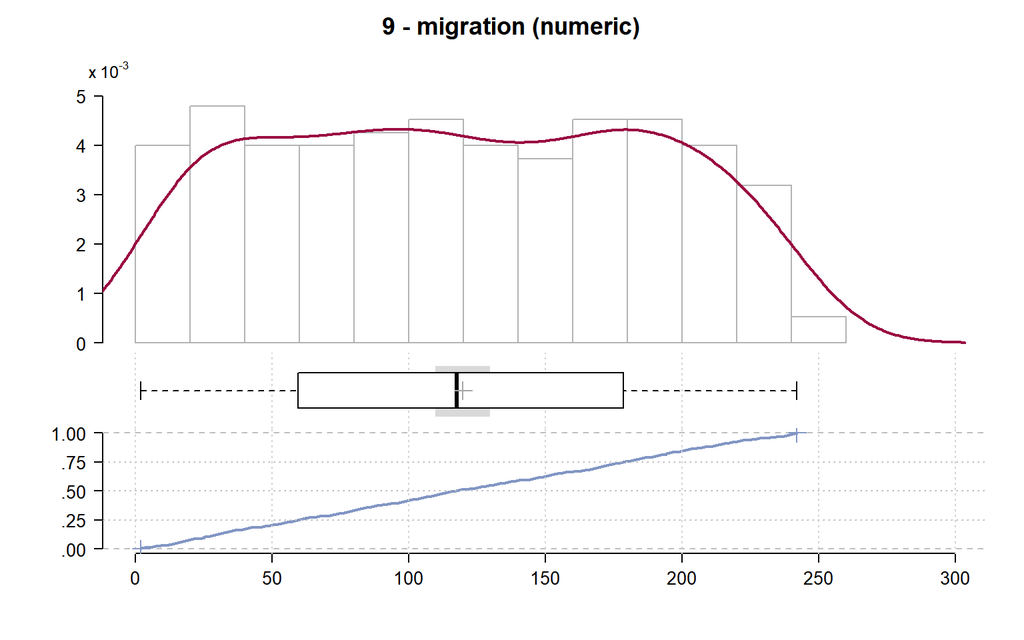

```
------------------------------------------------------------------------------
10 - 주민등록인구수 (integer)

        length           n        NAs      unique          0s        mean
           188         188          0         = n           0  193'754.14
                    100.0%       0.0%                    0.0%

           .05         .10        .25      median         .75         .90
     27'656.65   33'303.20  52'134.75  113'942.50  311'200.00  440'587.90

         range          sd      vcoef         mad         IQR        skew
  1'184'040.00  178'154.75       0.92  119'788.89  259'065.25        1.56

      meanCI
  168'121.91
  219'386.37

         .95
  501'469.75

        kurt
        4.13

lowest : 10'001, 17'713, 23'628, 24'010, 24'171
highest: 591'891, 595'485, 657'831, 662'154, 1'194'041
```

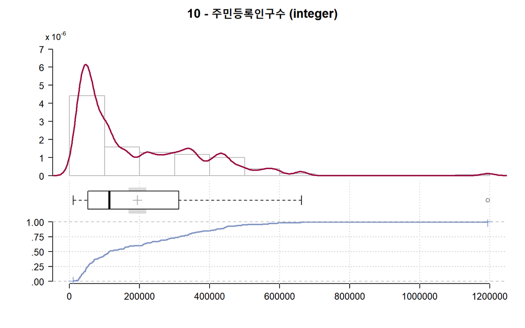

```
------------------------------------------------------------------------------
11 - t.rate (numeric)

      length           n         NAs      unique          0s        mean
         188         188           0         = n           0  0.04061096
                  100.0%        0.0%                    0.0%

         .05         .10         .25      median         .75         .90
  0.01647370  0.02050721  0.03029066  0.04060200  0.04971344  0.05797234

       range          sd       vcoef         mad         IQR        skew
  0.07498548  0.01476651  0.36360904  0.01407992  0.01942278  0.22213282

       meanCI
   0.03848641
   0.04273551

          .95
   0.06553814

         kurt
  -0.06175245

lowest : 0.01085216, 0.01318128, 0.01334563, 0.01342153, 0.01408009
highest: 0.07179431, 0.07321147, 0.07770532, 0.08268207, 0.08583764
```

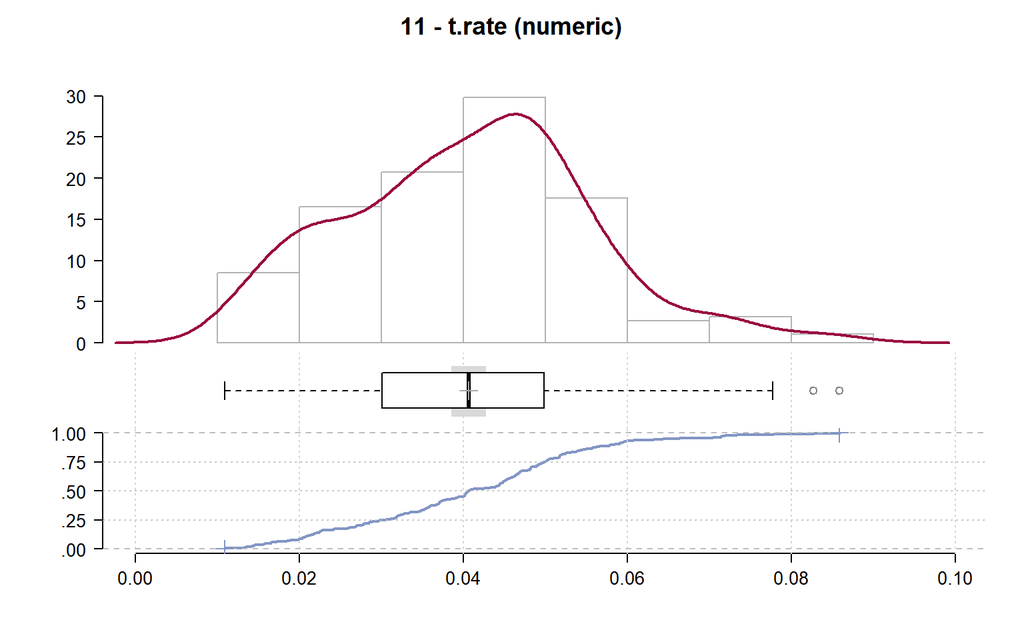

```r
DT::datatable(finaldata, rownames = FALSE, caption = "show finaldata")
```

| 지역명 | 수급자수 | GRDP | crime | cctv | police | 유입인구 | 유출인구 | migration | 주민등록인구수 | t.rate |
| --- | --- | --- | --- | --- | --- | --- | --- | --- | --- | --- |
| 강원도 강릉시 | 8722 | 4854518 | 126.91 | 30.91 | 542.76 | 30907 | 31404 | 99 | 213846 | 0.040786360277957 |
| 강원도 고성군 | 1355 | 951171 | 67.41 | 67.08 | 253.06 | 5011 | 4816 | 166 | 30114 | 0.0449956830709969 |
| 강원도 동해시 | 3623 | 2616335 | 100.43 | 53.59 | 407.41 | 10520 | 11151 | 115 | 93297 | 0.0388329742649817 |
| 강원도 삼척시 | 3343 | 2273273 | 120.69 | 31.03 | 319.26 | 8483 | 9508 | 3 | 69599 | 0.0480322993146453 |
| 강원도 양구군 | 1178 | 867428 | 54.56 | 77.05 | 237.72 | 3242 | 3384 | 24 | 24010 | 0.0490628904623074 |
| 강원도 영월군 | 1443 | 1297094 | 60.14 | 75.11 | 288.29 | 4385 | 4316 | 228 | 40073 | 0.0360092830584184 |
| 강원도 원주시 | 11630 | 7945326 | 130.66 | 20.53 | 627.05 | 57766 | 53491 | 202 | 337979 | 0.0344104219492927 |
| 강원도 인제군 | 1219 | 1381148 | 57.76 | 69.38 | 270.41 | 4022 | 4647 | 114 | 32720 | 0.0372555012224939 |
| 강원도 정선군 | 1423 | 1329883 | 123.2 | 72.32 | 248.19 | 3674 | 3963 | 62 | 38718 | 0.0367529314530709 |
| 강원도 철원군 | 1926 | 1592046 | 50.82 | 34.37 | 384.1 | 5072 | 5842 | 128 | 48013 | 0.0401141357548997 |

[output cut: 178 more lines]

## 3.4. 로그 취하기

### 3.4.1. 지역별 5대 범죄율

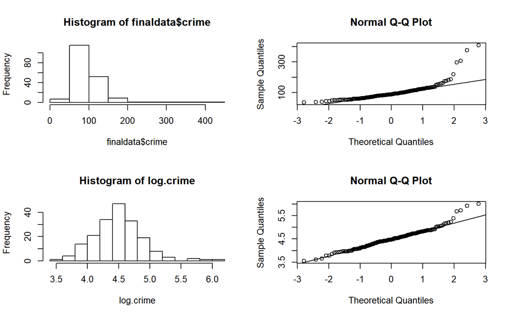

```r
# crime data
par(mfrow = c(2, 2))
hist(finaldata$crime)
qqnorm(finaldata$crime)
qqline(finaldata$crime)
log.crime <- log(finaldata$crime)
hist(log.crime)
qqnorm(log.crime)
qqline(log.crime)
```

```r
finaldata <- finaldata %>% mutate(log.crime)
```

### 3.4.2. 지역별 GRDP

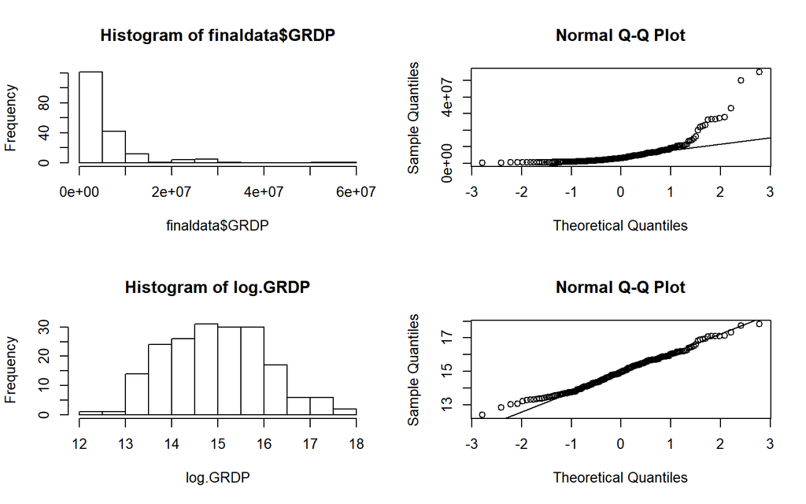

```r
# GRDP
par(mfrow = c(2, 2))
hist(finaldata$GRDP)
qqnorm(finaldata$GRDP)
qqline(finaldata$GRDP)
log.GRDP <- log(finaldata$GRDP)
hist(log.GRDP)
qqnorm(log.GRDP)
qqline(log.GRDP)
```

```r
finaldata <- finaldata %>% mutate(log.GRDP)
```

### 3.4.3. 지역별 1만명당 CCTV 대수

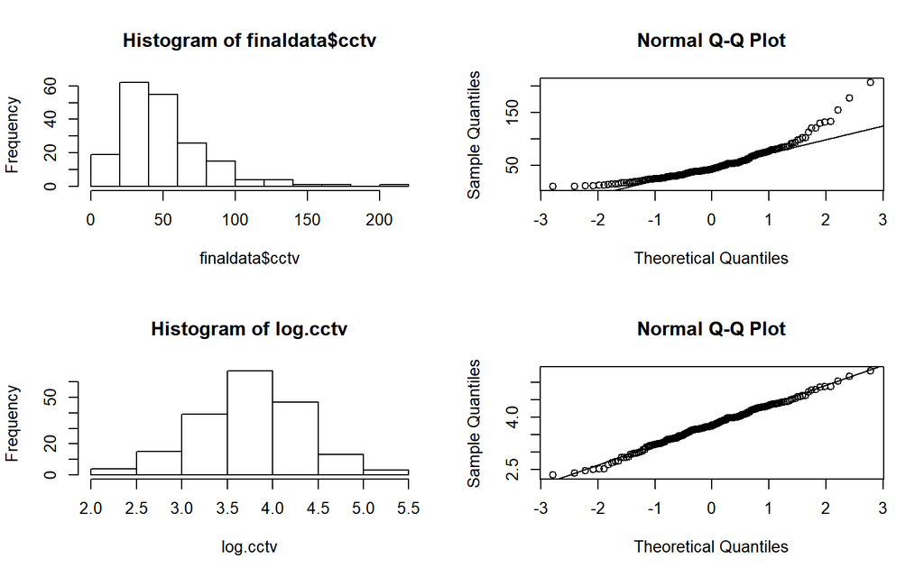

```r
par(mfrow = c(2, 2))
hist(finaldata$cctv)
qqnorm(finaldata$cctv)
qqline(finaldata$cctv)
log.cctv <- log(finaldata$cctv)
hist(log.cctv)
qqnorm(log.cctv)
qqline(log.cctv)
```

```r
finaldata <- finaldata %>% mutate(log.cctv)
```

### 3.4.4. Summary

```r
DT::datatable(finaldata, rownames = FALSE, caption = "after log")
```

| 지역명 | 수급자수 | GRDP | crime | cctv | police | 유입인구 | 유출인구 | migration | 주민등록인구수 | t.rate | log.crime | log.GRDP | log.cctv |
| --- | --- | --- | --- | --- | --- | --- | --- | --- | --- | --- | --- | --- | --- |
| 강원도 강릉시 | 8722 | 4854518 | 126.91 | 30.91 | 542.76 | 30907 | 31404 | 99 | 213846 | 0.040786360277957 | 4.84347817382207 | 15.3954203756853 | 3.43107975614403 |
| 강원도 고성군 | 1355 | 951171 | 67.41 | 67.08 | 253.06 | 5011 | 4816 | 166 | 30114 | 0.0449956830709969 | 4.21079337486535 | 13.7654491360891 | 4.20588593695501 |
| 강원도 동해시 | 3623 | 2616335 | 100.43 | 53.59 | 407.41 | 10520 | 11151 | 115 | 93297 | 0.0388329742649817 | 4.60946096740525 | 14.7772850414645 | 3.98136248350676 |
| 강원도 삼척시 | 3343 | 2273273 | 120.69 | 31.03 | 319.26 | 8483 | 9508 | 3 | 69599 | 0.0480322993146453 | 4.79322527462981 | 14.6367312012099 | 3.43495447846029 |
| 강원도 양구군 | 1178 | 867428 | 54.56 | 77.05 | 237.72 | 3242 | 3384 | 24 | 24010 | 0.0490628904623074 | 3.99930101353521 | 13.6732877902405 | 4.34445456176612 |
| 강원도 영월군 | 1443 | 1297094 | 60.14 | 75.11 | 288.29 | 4385 | 4316 | 228 | 40073 | 0.0360092830584184 | 4.09667517756038 | 14.0756369356146 | 4.31895370569792 |
| 강원도 원주시 | 11630 | 7945326 | 130.66 | 20.53 | 627.05 | 57766 | 53491 | 202 | 337979 | 0.0344104219492927 | 4.8725985294126 | 15.8880943892068 | 3.02188723103084 |
| 강원도 인제군 | 1219 | 1381148 | 57.76 | 69.38 | 270.41 | 4022 | 4647 | 114 | 32720 | 0.0372555012224939 | 4.05629649458457 | 14.1384255953676 | 4.2395986415416 |
| 강원도 정선군 | 1423 | 1329883 | 123.2 | 72.32 | 248.19 | 3674 | 3963 | 62 | 38718 | 0.0367529314530709 | 4.81380905109942 | 14.1006015264035 | 4.28110071608392 |
| 강원도 철원군 | 1926 | 1592046 | 50.82 | 34.37 | 384.1 | 5072 | 5842 | 128 | 48013 | 0.0401141357548997 | 3.92828997789202 | 14.2805305394414 | 3.53718409086174 |

[output cut: 178 more lines]

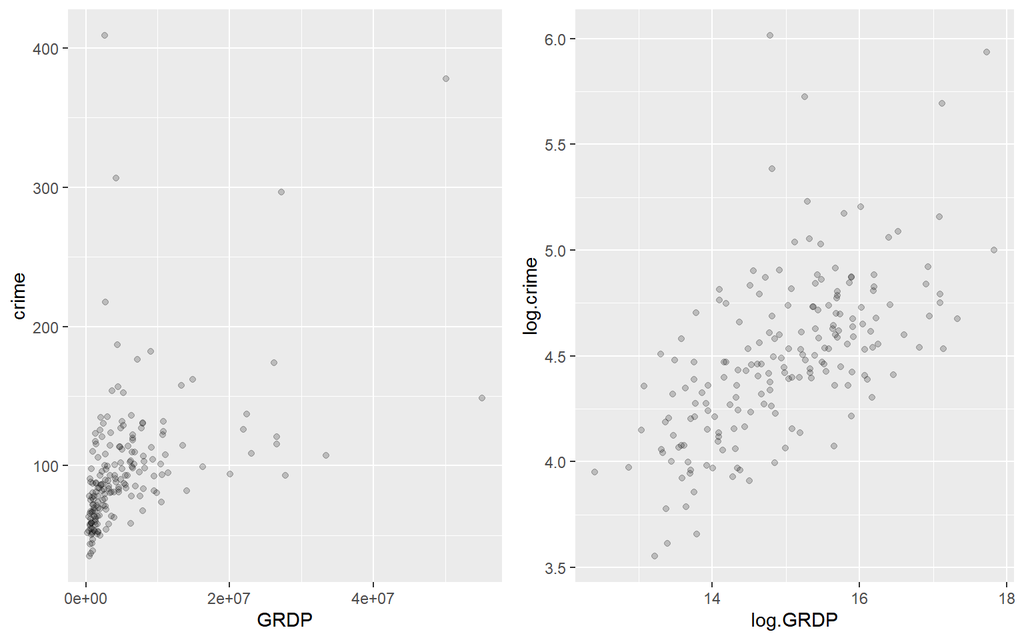

```r
p1 <- ggplot(data = finaldata, aes(y = crime, x = GRDP)) + geom_point(alpha = 0.2)
p2 <- ggplot(data = finaldata, aes(y = log.crime, x = log.GRDP)) + geom_point(alpha = 0.2)
grid.arrange(p1, p2, ncol = 2)
```

로그를 씌우기 전과 로그를 씌운 후 GRDP 변수와 종속변수인 범죄율의 관계가 어떻게 나타나는지를 살펴봤습니다. 눈으로 보기에도 두 변수 간의 관계가 양의 상관관계를 보임을 알 수 있지만, 로그 값을 적용함으로써 GRDP 변수가 미치는 영향을 조금 더 선명하게 확인할 수 있습니다.

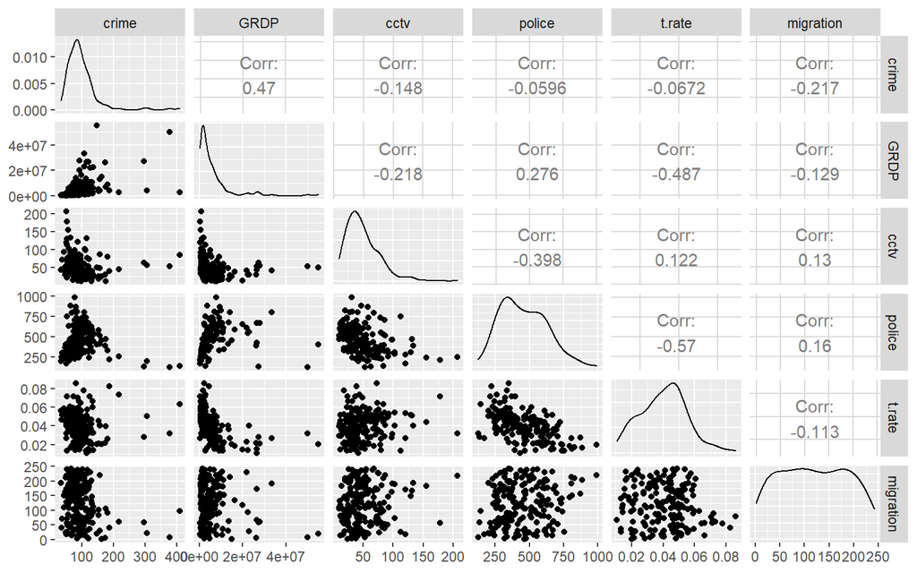

```r
ggpairs(data = finaldata, columns = c("crime", "GRDP", "cctv", "police", "t.rate",
    "migration"))
```

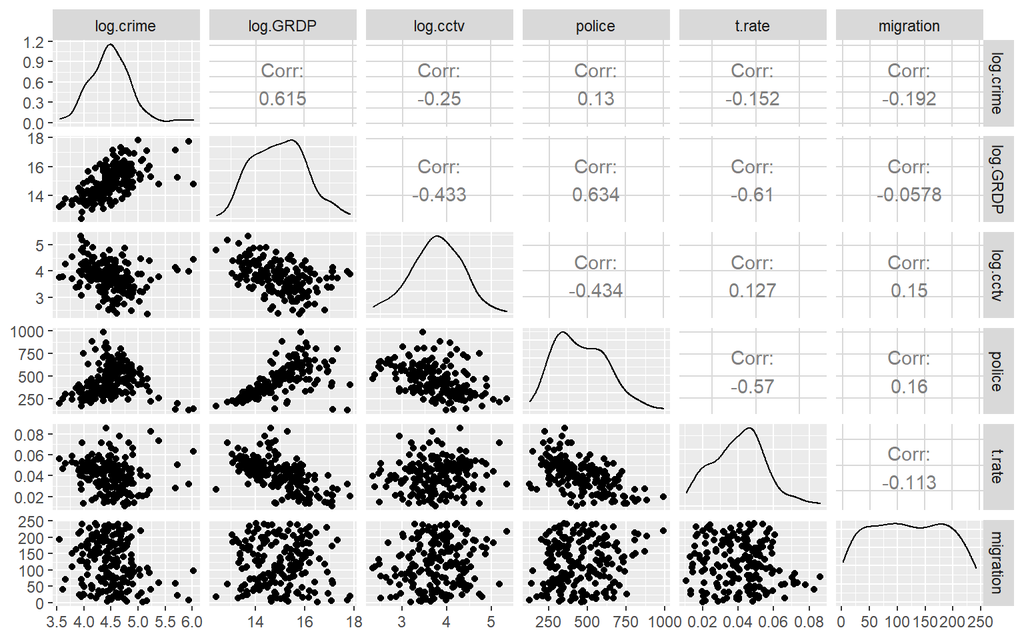

```r
ggpairs(data = finaldata, columns = c("log.crime", "log.GRDP", "log.cctv", "police",
    "t.rate", "migration"))
```

# 4. Analysis & Results

## 4.1. 단순선형회귀 분석

이번 연구는 다중회귀분석에 집중하지만, GRDP와 범죄와의 관계에 한해 단순선형회귀분석을 진행해보기로 했습니다.

### 4.1.1. 상관관계 분석 및 시각화

```r
cor.test(finaldata$log.GRDP, finaldata$log.crime)
```

```
    Pearson's product-moment correlation

data:  finaldata$log.GRDP and finaldata$log.crime
t = 10.624, df = 186, p-value < 2.2e-16
alternative hypothesis: true correlation is not equal to 0
95 percent confidence interval:
 0.5168939 0.6964074
sample estimates:
      cor
0.6145446
```

상관관계를 알아본 결과 log.GRDP와 log.crime은0.6145446으로 강한 양의 상관관계를 보였습니다.

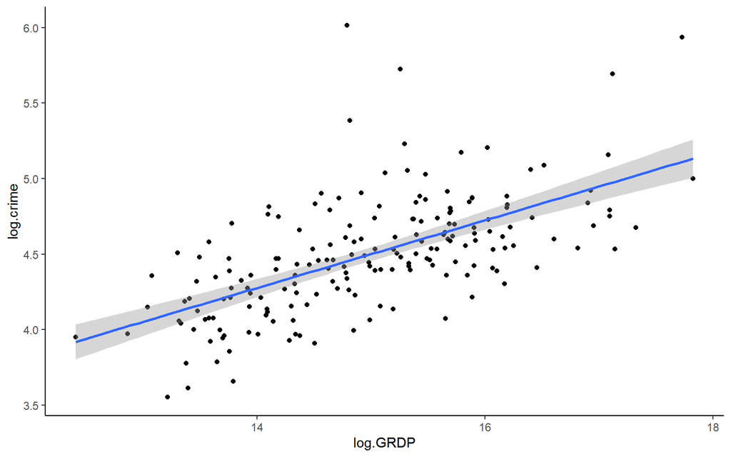

```r
ggplot(finaldata, aes(x = log.GRDP, y = log.crime)) + geom_point() + geom_smooth(method = "lm") +
    theme_classic()
```

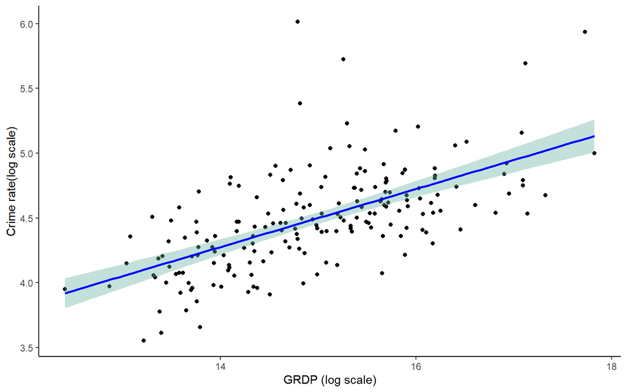

```r
p1 <- ggplot(finaldata, aes(x = log.GRDP, y = log.crime)) + geom_point() + xlab("GRDP (log scale)") +
    ylab("Crime rate(log scale)") + geom_smooth(method = lm, color = "blue", fill = "#69b3a2",
    se = TRUE) + theme_classic()
p1
```

위의 상관관계 분석을 시각화해봐도 눈에 띠게 양의 상관관계가 나타나는 것을 확인할 수 있습니다

### 4.1.2. 분석 검증

```r
mod1 <- lm(log.crime ~ log.GRDP, data = finaldata)
summary(mod1)
```

```
Call:
lm(formula = log.crime ~ log.GRDP, data = finaldata)

Residuals:
     Min       1Q   Median       3Q      Max
-0.57378 -0.18341 -0.03834  0.14911  1.56077

Coefficients:
            Estimate Std. Error t value Pr(>|t|)
(Intercept)  1.14477    0.31599   3.623 0.000376 ***
log.GRDP     0.22373    0.02106  10.624  < 2e-16 ***
---
Signif. codes:  0 '***' 0.001 '**' 0.01 '*' 0.05 '.' 0.1 ' ' 1

Residual standard error: 0.3068 on 186 degrees of freedom
Multiple R-squared:  0.3777,    Adjusted R-squared:  0.3743
F-statistic: 112.9 on 1 and 186 DF,  p-value: < 2.2e-16
```

```r
anova(mod1)
```

```
Analysis of Variance Table

Response: log.crime
           Df Sum Sq Mean Sq F value    Pr(>F)
log.GRDP    1 10.626 10.6258  112.87 < 2.2e-16 ***
Residuals 186 17.510  0.0941
---
Signif. codes:  0 '***' 0.001 '**' 0.01 '*' 0.05 '.' 0.1 ' ' 1
```

```r
tidy(mod1)
```

```
# A tibble: 2 x 5
  term        estimate std.error statistic  p.value
  <chr>          <dbl>     <dbl>     <dbl>    <dbl>
1 (Intercept)    1.14     0.316       3.62 3.76e- 4
2 log.GRDP       0.224    0.0211     10.6  6.59e-21
```

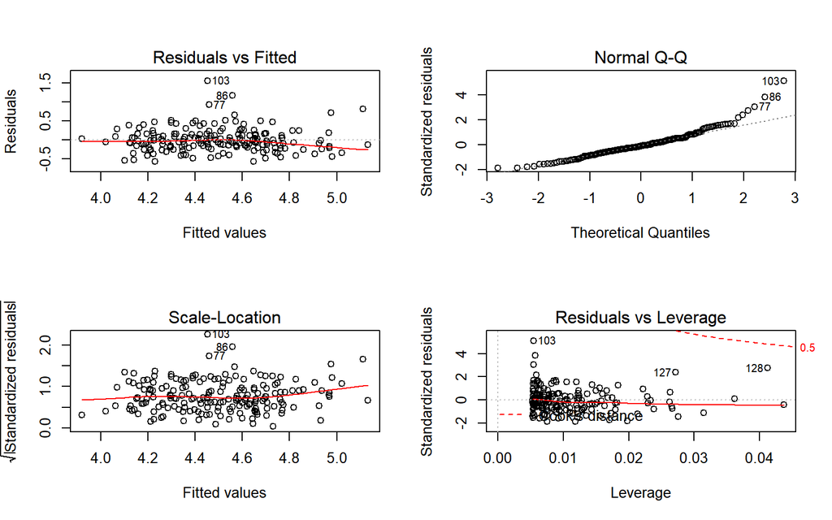

```r
par(mfrow = c(2, 2))
plot(mod1)
```

상관관계 분석에 대해 P-value와 결정계수를 확인해본 결과, p값이 0.05보다 확실하게 작아 유의미한 분석이라고 확인할 수 있을 뿐더러 결정계수 역시 0.3743으로 꽤 높은 확률로 설명 가능한 분석임을 확인할 수 있습니다.

### 4.1.3. 잔차(residuals)를 통한 검증

```r
shapiro.test(mod1$res)
```

```
    Shapiro-Wilk normality test

data:  mod1$res
W = 0.92963, p-value = 6.842e-08
```

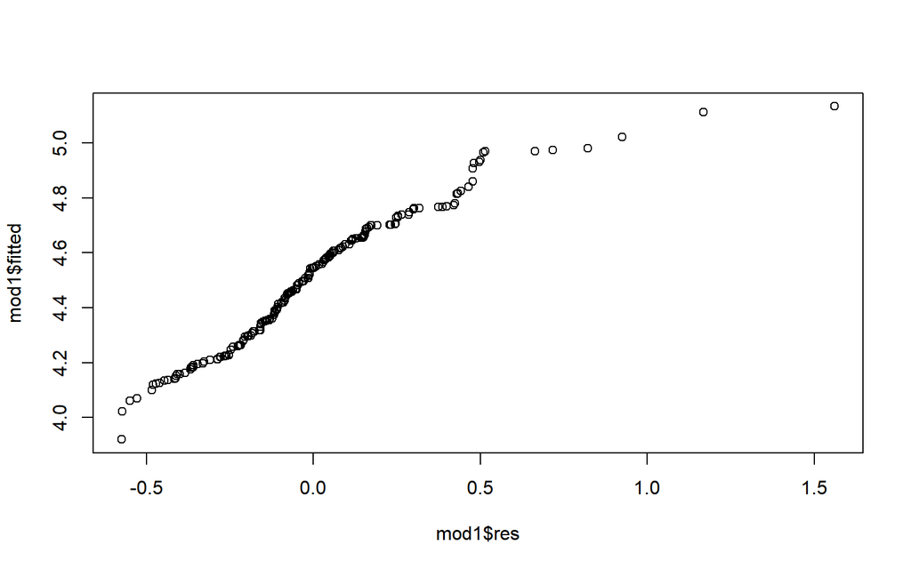

```r
qqplot(mod1$res, mod1$fitted)
```

```r
durbinWatsonTest(mod1)
```

```
 lag Autocorrelation D-W Statistic p-value
   1      0.06372597      1.868454   0.326
 Alternative hypothesis: rho != 0
```

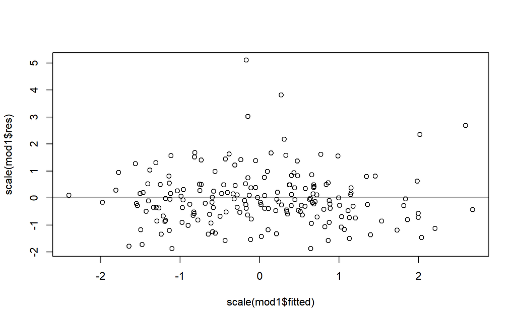

```r
plot(scale(mod1$fitted), scale(mod1$res))
abline(h = 0)
```

잔차를 살펴보았을 때에도, 잔차가 정규분포에 가까운 형태로 나타나지는 않았습니다. 따라서, 최종적으로 로그 값을 씌워 GRDP와 범죄 간의 상관관계를 단순회귀분석을 통해 알아본 결과, 양의 상관관계가 나타나는 것을 알 수 있습니다.

## 4.2. 다중회귀분석

### 4.2.1. 상관관계 분석

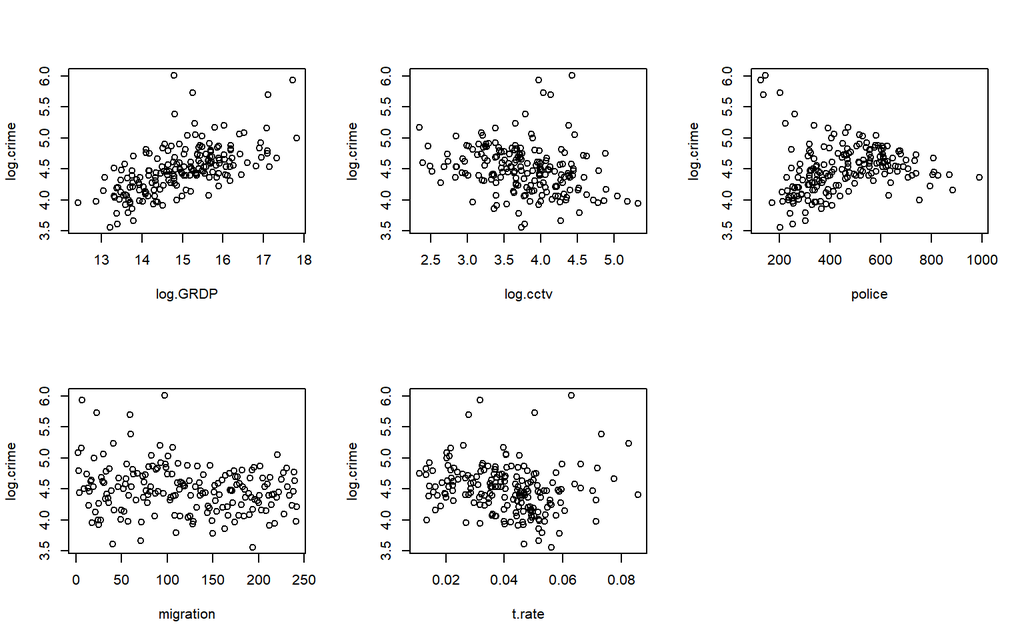

```r
par(mfrow = c(2, 3))
plot(log.crime ~ log.GRDP + log.cctv + police + migration + t.rate, data = finaldata)
abline()
```

```r
mod4 <- lm(log.crime ~ log.GRDP + log.cctv + police + migration + t.rate, data = finaldata)
summary(mod4)
```

```
Call:
lm(formula = log.crime ~ log.GRDP + log.cctv + police + migration +
    t.rate, data = finaldata)

Residuals:
     Min       1Q   Median       3Q      Max
-0.62652 -0.17008 -0.02112  0.15570  1.18872

Coefficients:
              Estimate Std. Error t value Pr(>|t|)
(Intercept) -0.6951759  0.5248531  -1.325 0.186993
log.GRDP     0.3553564  0.0278827  12.745  < 2e-16 ***
log.cctv     0.0012125  0.0416701   0.029 0.976819
police      -0.0007838  0.0001729  -4.534 1.05e-05 ***
migration   -0.0003017  0.0003040  -0.993 0.322174
t.rate       6.3944769  1.8456417   3.465 0.000662 ***
---
Signif. codes:  0 '***' 0.001 '**' 0.01 '*' 0.05 '.' 0.1 ' ' 1

Residual standard error: 0.27 on 182 degrees of freedom
Multiple R-squared:  0.5284,    Adjusted R-squared:  0.5155
F-statistic: 40.79 on 5 and 182 DF,  p-value: < 2.2e-16
```

```r
anova(mod4)
```

```
Analysis of Variance Table

Response: log.crime
           Df  Sum Sq Mean Sq  F value    Pr(>F)
log.GRDP    1 10.6258 10.6258 145.7524 < 2.2e-16 ***
log.cctv    1  0.0088  0.0088   0.1202 0.7292397
police      1  3.2488  3.2488  44.5628 2.881e-10 ***
migration   1  0.1087  0.1087   1.4914 0.2235853
t.rate      1  0.8751  0.8751  12.0037 0.0006621 ***
Residuals 182 13.2684  0.0729
---
Signif. codes:  0 '***' 0.001 '**' 0.01 '*' 0.05 '.' 0.1 ' ' 1
```

다중회귀분석을 적용해본 결과 여러 가지 변수와 범죄와의 상관관계에 대해 알아볼 수 있었고, 결정계수와 p값 역시 분석의 유의미함을 뒷받침해주었습니다. 하지만, 일부 변수들의 경우 p값이 0.05를 초과해 밑에서 다중회귀분석의 여러 변수선택방식을 적용해보기로 결정했습니다.

```r
confint(mod4)  # 회귀계수 95% 신뢰구간
```

```
                    2.5 %        97.5 %
(Intercept) -1.7307550825  0.3404033557
log.GRDP     0.3003415221  0.4103712293
log.cctv    -0.0810061879  0.0834311012
police      -0.0011248429 -0.0004426676
migration   -0.0009014686  0.0002979940
t.rate       2.7528705495 10.0360832058
```

```r
tidy(mod4)
```

```
# A tibble: 6 x 5
  term         estimate std.error statistic  p.value
  <chr>           <dbl>     <dbl>     <dbl>    <dbl>
1 (Intercept) -0.695     0.525      -1.32   1.87e- 1
2 log.GRDP     0.355     0.0279     12.7    5.28e-27
3 log.cctv     0.00121   0.0417      0.0291 9.77e- 1
4 police      -0.000784  0.000173   -4.53   1.05e- 5
5 migration   -0.000302  0.000304   -0.993  3.22e- 1
6 t.rate       6.39      1.85        3.46   6.62e- 4
```

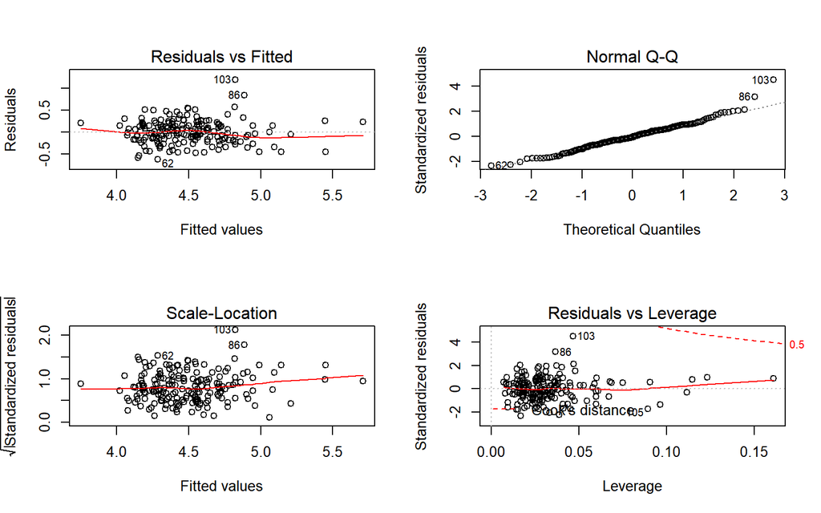

```r
par(mfrow = c(2, 2))
plot(mod4)
```

### 4.2.2. 전진선택법(forward selection)

```r
summary(step(mod4, direction = "forward"))
```

```
Start:  AIC=-486.4
log.crime ~ log.GRDP + log.cctv + police + migration + t.rate
```

```
Call:
lm(formula = log.crime ~ log.GRDP + log.cctv + police + migration +
    t.rate, data = finaldata)

Residuals:
     Min       1Q   Median       3Q      Max
-0.62652 -0.17008 -0.02112  0.15570  1.18872

Coefficients:
              Estimate Std. Error t value Pr(>|t|)
(Intercept) -0.6951759  0.5248531  -1.325 0.186993
log.GRDP     0.3553564  0.0278827  12.745  < 2e-16 ***
log.cctv     0.0012125  0.0416701   0.029 0.976819
police      -0.0007838  0.0001729  -4.534 1.05e-05 ***
migration   -0.0003017  0.0003040  -0.993 0.322174
t.rate       6.3944769  1.8456417   3.465 0.000662 ***
---
Signif. codes:  0 '***' 0.001 '**' 0.01 '*' 0.05 '.' 0.1 ' ' 1

Residual standard error: 0.27 on 182 degrees of freedom
Multiple R-squared:  0.5284,    Adjusted R-squared:  0.5155
F-statistic: 40.79 on 5 and 182 DF,  p-value: < 2.2e-16
```

독립변수 중 종속변수에 가장 큰 영향을 주는 변수부터 모형에 포함하는 전진선택법을 적용해봤습니다. 위 분석 결과는 p값이 기각역 0.05보다 확실하게 작게 나타나 귀무가설이 기각되고, 설명계수 역시 0.5155로 비교적 높게 나타나 의미 있는 분석이라고 볼 수 있습니다.

### 4.2.3. 후진제거법(backward elimination)

```r
backward <- step(mod4, direction = "backward")
```

```
Start:  AIC=-486.4
log.crime ~ log.GRDP + log.cctv + police + migration + t.rate

            Df Sum of Sq    RSS     AIC
- log.cctv   1    0.0001 13.268 -488.40
- migration  1    0.0718 13.340 -487.38
<none>                   13.268 -486.40
- t.rate     1    0.8751 14.143 -476.39
- police     1    1.4985 14.767 -468.28
- log.GRDP   1   11.8415 25.110 -368.48

Step:  AIC=-488.4
log.crime ~ log.GRDP + police + migration + t.rate

            Df Sum of Sq    RSS     AIC
- migration  1    0.0736 13.342 -489.36
<none>                   13.268 -488.40
- t.rate     1    0.9355 14.204 -477.59
- police     1    1.6996 14.968 -467.74
- log.GRDP   1   12.8049 26.073 -363.40

Step:  AIC=-489.36
log.crime ~ log.GRDP + police + t.rate

           Df Sum of Sq    RSS     AIC
<none>                  13.342 -489.36
- t.rate    1    1.0141 14.356 -477.59
- police    1    1.9397 15.282 -465.84
- log.GRDP  1   14.0654 27.407 -356.02
```

```r
summary(backward)
```

```
Call:
lm(formula = log.crime ~ log.GRDP + police + t.rate, data = finaldata)

Residuals:
    Min      1Q  Median      3Q     Max
-0.6177 -0.1647 -0.0211  0.1552  1.1817

Coefficients:
              Estimate Std. Error t value Pr(>|t|)
(Intercept) -0.8107103  0.4023128  -2.015 0.045347 *
log.GRDP     0.3615319  0.0259581  13.928  < 2e-16 ***
police      -0.0008201  0.0001586  -5.172 6.01e-07 ***
t.rate       6.5950486  1.7635095   3.740 0.000246 ***
---
Signif. codes:  0 '***' 0.001 '**' 0.01 '*' 0.05 '.' 0.1 ' ' 1

Residual standard error: 0.2693 on 184 degrees of freedom
Multiple R-squared:  0.5258,    Adjusted R-squared:  0.5181
F-statistic: 68.01 on 3 and 184 DF,  p-value: < 2.2e-16
```

위와 반대로, 독립변수를 모두 포함한 모형에서 가장 영향이 적은 변수부터 제거하는 후진 제거법을 적용해봤습니다, 위 분석 결과는 p값이 0.05보다 매우 작게 나타나, 귀무가설이 기각돼 상관관계의 존재가 유력해지며, 설명계수 역시 0.5181로 비교적 높게 나타나 의미 있는 분석이라고 판단할 수 있을 것입니다.

### 4.2.4. 단계별(stepwise method)

```r
summary(step(mod4, direction = "both"))
```

```
Start:  AIC=-486.4
log.crime ~ log.GRDP + log.cctv + police + migration + t.rate

            Df Sum of Sq    RSS     AIC
- log.cctv   1    0.0001 13.268 -488.40
- migration  1    0.0718 13.340 -487.38
<none>                   13.268 -486.40
- t.rate     1    0.8751 14.143 -476.39
- police     1    1.4985 14.767 -468.28
- log.GRDP   1   11.8415 25.110 -368.48

Step:  AIC=-488.4
log.crime ~ log.GRDP + police + migration + t.rate

            Df Sum of Sq    RSS     AIC
- migration  1    0.0736 13.342 -489.36
<none>                   13.268 -488.40
+ log.cctv   1    0.0001 13.268 -486.40
- t.rate     1    0.9355 14.204 -477.59
- police     1    1.6996 14.968 -467.74
- log.GRDP   1   12.8049 26.073 -363.40

Step:  AIC=-489.36
log.crime ~ log.GRDP + police + t.rate

            Df Sum of Sq    RSS     AIC
<none>                   13.342 -489.36
+ migration  1    0.0736 13.268 -488.40
+ log.cctv   1    0.0018 13.340 -487.38
- t.rate     1    1.0141 14.356 -477.59
- police     1    1.9397 15.282 -465.84
- log.GRDP   1   14.0654 27.407 -356.02
```

```
Call:
lm(formula = log.crime ~ log.GRDP + police + t.rate, data = finaldata)

Residuals:
    Min      1Q  Median      3Q     Max
-0.6177 -0.1647 -0.0211  0.1552  1.1817

Coefficients:
              Estimate Std. Error t value Pr(>|t|)
(Intercept) -0.8107103  0.4023128  -2.015 0.045347 *
log.GRDP     0.3615319  0.0259581  13.928  < 2e-16 ***
police      -0.0008201  0.0001586  -5.172 6.01e-07 ***
t.rate       6.5950486  1.7635095   3.740 0.000246 ***
---
Signif. codes:  0 '***' 0.001 '**' 0.01 '*' 0.05 '.' 0.1 ' ' 1

Residual standard error: 0.2693 on 184 degrees of freedom
Multiple R-squared:  0.5258,    Adjusted R-squared:  0.5181
F-statistic: 68.01 on 3 and 184 DF,  p-value: < 2.2e-16
```

마지막으로, 전진선택법에 의해 변수를 추가하고, 변수 추가시 기존의 변수 중요도가 정해진 유의수준에 포함되지 않으면 앞에서 들어간 변수도 다시 제거하는 단계별 방법을 적용해봤습니다. 위 분석 결과는, 앞에서 적용한 후진제거법과 동일한 결과가 나타났으며, 따라서 유의미한 분석이라는 판단을 내릴 수 있을 것입니다.

### 4.2.5. 모델피팅(fit model)

```r
fit <- backward
summary(fit)
```

```
Call:
lm(formula = log.crime ~ log.GRDP + police + t.rate, data = finaldata)

Residuals:
    Min      1Q  Median      3Q     Max
-0.6177 -0.1647 -0.0211  0.1552  1.1817

Coefficients:
              Estimate Std. Error t value Pr(>|t|)
(Intercept) -0.8107103  0.4023128  -2.015 0.045347 *
log.GRDP     0.3615319  0.0259581  13.928  < 2e-16 ***
police      -0.0008201  0.0001586  -5.172 6.01e-07 ***
t.rate       6.5950486  1.7635095   3.740 0.000246 ***
---
Signif. codes:  0 '***' 0.001 '**' 0.01 '*' 0.05 '.' 0.1 ' ' 1

Residual standard error: 0.2693 on 184 degrees of freedom
Multiple R-squared:  0.5258,    Adjusted R-squared:  0.5181
F-statistic: 68.01 on 3 and 184 DF,  p-value: < 2.2e-16
```

```r
confint(fit)
```

```
                  2.5 %        97.5 %
(Intercept) -1.60444947 -0.0169710331
log.GRDP     0.31031812  0.4127456821
police      -0.00113289 -0.0005072498
t.rate       3.11574919 10.0743479429
```

```r
tidy(fit)
```

```
# A tibble: 4 x 5
  term         estimate std.error statistic  p.value
  <chr>           <dbl>     <dbl>     <dbl>    <dbl>
1 (Intercept) -0.811     0.402        -2.02 4.53e- 2
2 log.GRDP     0.362     0.0260       13.9  1.41e-30
3 police      -0.000820  0.000159     -5.17 6.01e- 7
4 t.rate       6.60      1.76          3.74 2.46e- 4
```

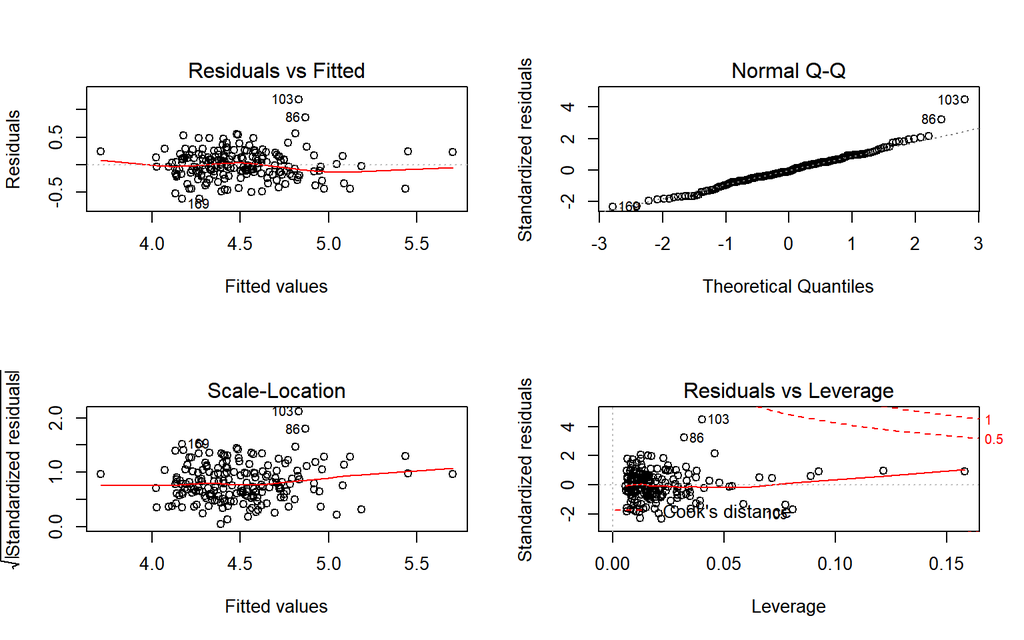

```r
par(mfrow = c(2, 2))
plot(fit)
```

### 4.2.6. 독립성 검정(Durbin-Watson test)

```r
durbinWatsonTest(fit)
```

```
 lag Autocorrelation D-W Statistic p-value
   1      0.05403652      1.886683   0.438
 Alternative hypothesis: rho != 0
```

### 4.2.7. 선형성검정

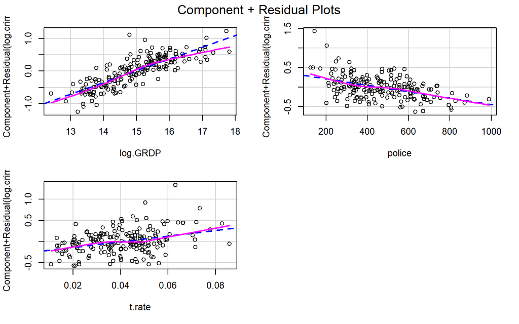

```r
crPlots(fit)
```

선형성을 검정한 결과, 변수들이 모두 선형 관계를 보이므로 선형성가정에 부합합니다.

### 4.2.8. 등분산성 검정(Homoscedasticity)

```r
ncvTest(fit)
```

```
Non-constant Variance Score Test
Variance formula: ~ fitted.values
Chisquare = 4.33615, Df = 1, p = 0.037311
```

### 4.2.9. 다중공선성 검정(Multicollinearity)

```r
vif(mod4)
```

```
 log.GRDP  log.cctv    police migration    t.rate
 2.263832  1.458784  2.170284  1.127152  1.905225
```

```r
sqrt(vif(mod4)) > 2
```

```
 log.GRDP  log.cctv    police migration    t.rate
    FALSE     FALSE     FALSE     FALSE     FALSE
```

## 4.3. Influence Statistics

### 4.3.1. 잔차 확인 및 분석

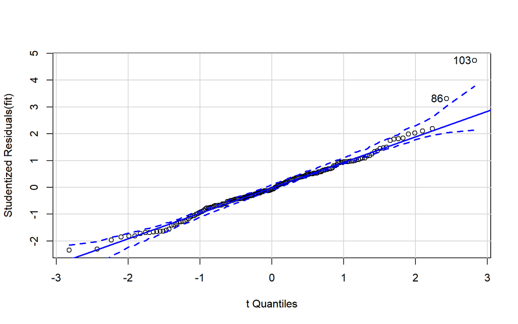

```
[1]  86 103
```

```r
qqPlot(fit, labels = row.names(지역명), id.method = "identify", simulate = TRUE)
```

잔차에 대한 분석을 실행한 결과 86번 데이터와 103번 데이터가 회귀식에서의 잔차가 크게 나타나 이상치일 수도 있음을 의심하게 만들었습니다. 이에 103번 데이터를 확인해보기로 했습니다.

```r
finaldata["103", -c(6, 7, 8, 10)]
```

```
             지역명 수급자수    GRDP crime  cctv migration     t.rate log.crime
103 부산광역시 중구     2850 2640768   409 84.28        97 0.06304194  6.013715
    log.GRDP log.cctv
103 14.78658 4.434145
```

```r
fitted(fit)["103"]
```

```
     103
4.832047
```

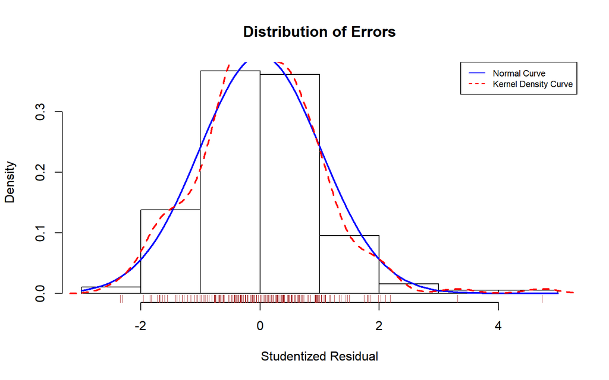

```r
residplot <- function(finaldata, nbreaks = 10) {
    z <- rstudent(fit)
    hist(z, breaks = nbreaks, freq = FALSE, xlab = "Studentized Residual", main = "Distribution of Errors")
    rug(jitter(z), col = "brown")
    curve(dnorm(x, mean = mean(z), sd = sd(z)), add = TRUE, col = "blue", lwd = 2)
    lines(density(z)$x, density(z)$y, col = "red", lwd = 2, lty = 2)
    legend("topright", legend = c("Normal Curve", "Kernel Density Curve"), lty = 1:2,
        col = c("blue", "red"), cex = 0.7)
}
residplot(fit)
```

### 4.3.2. Hat Matrix

```r
inf.fit <- influence.measures(fit)
print(round(inf.fit$infmat, 4), 3)
```

```
     dfb.1_ dfb.l.GR dfb.polc dfb.t.rt   dffit cov.r cook.d    hat
1   -0.0267   0.0193   0.0322   0.0320  0.0874 1.008 0.0019 0.0078
2   -0.0124   0.0087   0.0101   0.0088 -0.0219 1.039 0.0001 0.0171
3    0.0131  -0.0058  -0.0144  -0.0160  0.0470 1.021 0.0006 0.0066
4   -0.0107   0.0220  -0.0508   0.0114  0.0937 1.011 0.0022 0.0094
5   -0.0638   0.0459   0.0572   0.0318 -0.1282 1.018 0.0041 0.0168
6   -0.0588   0.0373   0.0488   0.0646 -0.0972 1.032 0.0024 0.0198
7   -0.0319   0.0246   0.0416   0.0204  0.0924 1.018 0.0021 0.0118
8   -0.0736   0.0409   0.0828   0.0876 -0.1416 1.020 0.0050 0.0194
9    0.1407  -0.0735  -0.1752  -0.1769  0.2803 0.971 0.0194 0.0226
 [ getOption("max.print") 에 도달했습니다 -- 179 행들을 생략합니다 ]
```

### 4.3.3. Cook’s distance

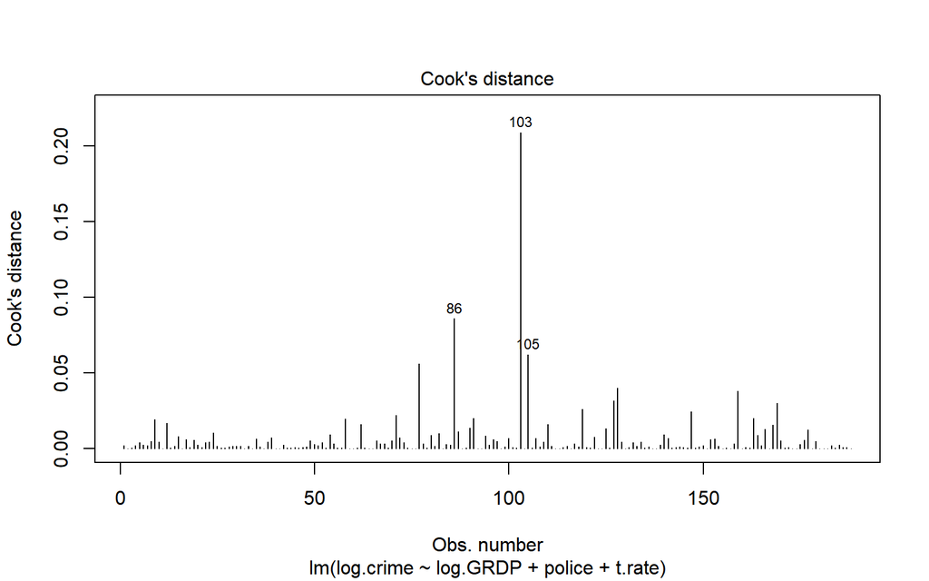

```r
plot(fit, which = 4)
```

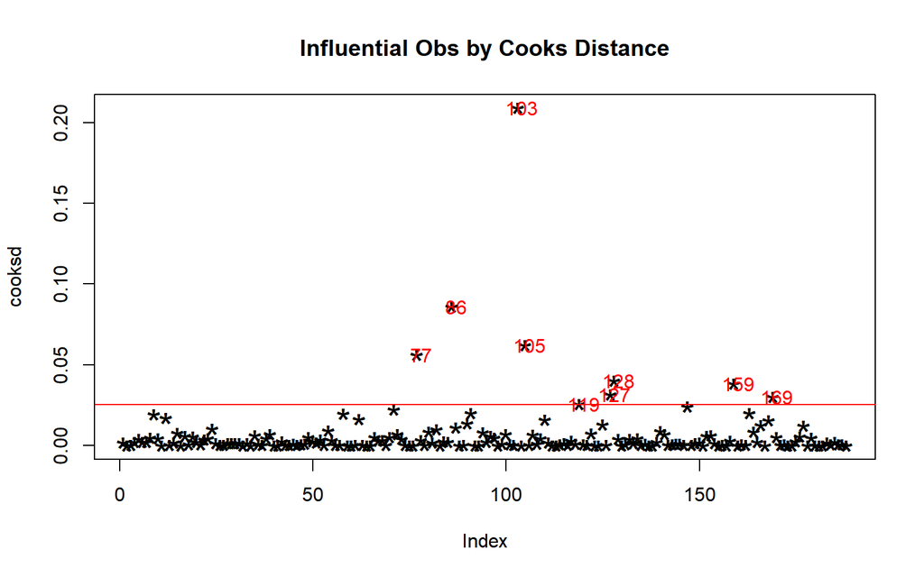

```r
cooksd <- cooks.distance(fit)
plot(cooksd, pch = "*", cex = 2, main = "Influential Obs by Cooks Distance")
abline(h = 4 * mean(cooksd, na.rm = T), col = "red")
text(x = 1:length(cooksd) + 1, y = cooksd, labels = ifelse(cooksd > 4 * mean(cooksd,
    na.rm = T), names(cooksd), ""), col = "red")
```

Cook’s distance를 통해 아웃라이어의 존재에 대해서 확인해본 결과, 기준선의 위쪽에 일부 수치들이 존재하지만, 거의 대부분의 수치가 아래쪽에 위치함을 확인할 수 있습니다.